# DSPM_HW2_dchand

```python
import pandas as pd
import numpy as np
import matplotlib.pyplot as plt
import seaborn as sns
```

```python
# Load data from the CSV file
data = pd.read_csv('analytic_data2022.csv')
data.head()
```

|  | State FIPS Code | County FIPS Code | 5-digit FIPS Code | State Abbreviation | Name | Release Year | County Ranked (Yes=1/No=0) | Premature death raw value | Premature death numerator | Premature death denominator | ... | % female raw value | % female numerator | % female denominator | % female CI low | % female CI high | % rural raw value | % rural numerator | % rural denominator | % rural CI low | % rural CI high |
| --- | --- | --- | --- | --- | --- | --- | --- | --- | --- | --- | --- | --- | --- | --- | --- | --- | --- | --- | --- | --- | --- |
| 0 | statecode | countycode | fipscode | state | county | year | county_ranked | v001_rawvalue | v001_numerator | v001_denominator | ... | v057_rawvalue | v057_numerator | v057_denominator | v057_cilow | v057_cihigh | v058_rawvalue | v058_numerator | v058_denominator | v058_cilow | v058_cihigh |
| 1 | 00 | 000 | 00000 | US | United States | 2022 | NaN | 7281.9355638 | 4125218 | 917267406 | ... | 0.5075447019 | 167227921 | 329484123 | NaN | NaN | 0.1926902892 | NaN | NaN | NaN | NaN |
| 2 | 01 | 000 | 01000 | AL | Alabama | 2022 | NaN | 10350.071456 | 88086 | 13668498 | ... | 0.5170272184 | 2544566 | 4921532 | NaN | NaN | 0.409631829 | 1957932 | 4779736 | NaN | NaN |
| 3 | 01 | 001 | 01001 | AL | Autauga County | 2022 | 1 | 8027.3947267 | 836 | 156081 | ... | 0.5150770327 | 28919 | 56145 | NaN | NaN | 0.4200216232 | 22921 | 54571 | NaN | NaN |
| 4 | 01 | 003 | 01003 | AL | Baldwin County | 2022 | 1 | 8118.3582061 | 3377 | 614143 | ... | 0.5158905651 | 118287 | 229287 | NaN | NaN | 0.4227909911 | 77060 | 182265 | NaN | NaN |

5 rows × 725 columns

```python
# Select columns to keep in the data including columns with 'raw' values
cols = ['State FIPS Code', 'County FIPS Code', '5-digit FIPS Code', 'State Abbreviation', 'Name', 'Release Year','County Ranked (Yes=1/No=0)'] + data.filter(regex='raw value').columns.tolist()
data = data[cols]
data
```

|  | State FIPS Code | County FIPS Code | 5-digit FIPS Code | State Abbreviation | Name | Release Year | County Ranked (Yes=1/No=0) | Premature death raw value | Poor or fair health raw value | Poor physical health days raw value | ... | % 65 and older raw value | % non-Hispanic Black raw value | % American Indian & Alaska Native raw value | % Asian raw value | % Native Hawaiian/Other Pacific Islander raw value | % Hispanic raw value | % non-Hispanic white raw value | % not proficient in English raw value | % female raw value | % rural raw value |
| --- | --- | --- | --- | --- | --- | --- | --- | --- | --- | --- | --- | --- | --- | --- | --- | --- | --- | --- | --- | --- | --- |
| 0 | statecode | countycode | fipscode | state | county | year | county_ranked | v001_rawvalue | v002_rawvalue | v036_rawvalue | ... | v053_rawvalue | v054_rawvalue | v055_rawvalue | v081_rawvalue | v080_rawvalue | v056_rawvalue | v126_rawvalue | v059_rawvalue | v057_rawvalue | v058_rawvalue |
| 1 | 00 | 000 | 00000 | US | United States | 2022 | NaN | 7281.9355638 | 0.1710516277 | 3.9073588699 | ... | 0.1689288227 | 0.1257339523 | 0.013029429 | 0.0607382165 | 0.0025606484 | 0.1860875069 | 0.597216607 | 0.0415967215 | 0.5075447019 | 0.1926902892 |
| 2 | 01 | 000 | 01000 | AL | Alabama | 2022 | NaN | 10350.071456 | 0.2141018928 | 4.8146328442 | ... | 0.1776365571 | 0.2649081627 | 0.0070906783 | 0.0153511142 | 0.001095797 | 0.0460338366 | 0.6513778636 | 0.0101944794 | 0.5170272184 | 0.409631829 |
| 3 | 01 | 001 | 01001 | AL | Autauga County | 2022 | 1 | 8027.3947267 | 0.201 | 4.5100424038 | ... | 0.1617597293 | 0.2031881735 | 0.0047377327 | 0.0117018434 | 0.0010864725 | 0.0310089946 | 0.731659097 | 0.0069269521 | 0.5150770327 | 0.4200216232 |
| 4 | 01 | 003 | 01003 | AL | Baldwin County | 2022 | 1 | 8118.3582061 | 0.172 | 4.168866136 | ... | 0.2158212197 | 0.0847889326 | 0.0077980871 | 0.0110298447 | 0.0006629246 | 0.046339304 | 0.8330825559 | 0.0077206791 | 0.5158905651 | 0.4227909911 |
| ... | ... | ... | ... | ... | ... | ... | ... | ... | ... | ... | ... | ... | ... | ... | ... | ... | ... | ... | ... | ... | ... |
| 3190 | 56 | 37 | 56037 | WY | Sweetwater County | 2022 | 1.0 | 8419.275418 | 0.163 | 3.495993 | ... | 0.137417 | 0.010991 | 0.014482 | 0.010077 | 0.001781 | 0.161882 | 0.791953 | 0.007929 | 0.483608 | 0.109163 |
| 3191 | 56 | 39 | 56039 | WY | Teton County | 2022 | 1.0 | 3283.066198 | 0.116 | 2.779692 | ... | 0.165979 | 0.007363 | 0.009916 | 0.015491 | 0.001787 | 0.149508 | 0.810146 | 0.029942 | 0.481338 | 0.464309 |
| 3192 | 56 | 41 | 56041 | WY | Uinta County | 2022 | 1.0 | 9358.208153 | 0.172 | 3.792121 | ... | 0.156567 | 0.005689 | 0.016077 | 0.005293 | 0.001583 | 0.099035 | 0.868068 | 0.012533 | 0.49394 | 0.430959 |
| 3193 | 56 | 43 | 56043 | WY | Washakie County | 2022 | 1.0 | 7073.941804 | 0.173 | 3.660729 | ... | 0.232861 | 0.00451 | 0.016753 | 0.008634 | 0.000773 | 0.141624 | 0.824742 | 0.002136 | 0.490464 | 0.359545 |
| 3194 | 56 | 45 | 56045 | WY | Weston County | 2022 | 1.0 | 5149.435226 | 0.16 | 3.703659 | ... | 0.224677 | 0.006822 | 0.019872 | 0.014534 | 0.000297 | 0.04108 | 0.900638 | 0.00197 | 0.475308 | 0.545366 |

3195 rows × 93 columns

```python
# Select specific columns to create a new DataFrame
df = data[['State FIPS Code', 'County FIPS Code', '5-digit FIPS Code', 'State Abbreviation', 'Name', 'Release Year','County Ranked (Yes=1/No=0)',
       'Adult smoking raw value', 'Adult obesity raw value',
       'Food environment index raw value', 'Physical inactivity raw value',
       'Access to exercise opportunities raw value',
       'Excessive drinking raw value',
       'Alcohol-impaired driving deaths raw value',
       'Sexually transmitted infections raw value', 'Teen births raw value',
       'Uninsured raw value', 'Primary care physicians raw value',
       'Dentists raw value', 'Mental health providers raw value',
       'Preventable hospital stays raw value',
       'Mammography screening raw value', 'Flu vaccinations raw value',
       'High school completion raw value', 'Some college raw value',
       'Unemployment raw value', 'Children in poverty raw value',
       'Income inequality raw value',
       'Children in single-parent households raw value',
       'Social associations raw value', 'Violent crime raw value',
       'Injury deaths raw value',
       'Air pollution - particulate matter raw value',
       'Drinking water violations raw value',
       'Severe housing problems raw value', 'Driving alone to work raw value',
       'Long commute - driving alone raw value','Premature death raw value','Poor or fair health raw value', 'Poor physical health days raw value',
       'Poor mental health days raw value', 'Low birthweight raw value']]
df
```

|  | State FIPS Code | County FIPS Code | 5-digit FIPS Code | State Abbreviation | Name | Release Year | County Ranked (Yes=1/No=0) | Adult smoking raw value | Adult obesity raw value | Food environment index raw value | ... | Air pollution - particulate matter raw value | Drinking water violations raw value | Severe housing problems raw value | Driving alone to work raw value | Long commute - driving alone raw value | Premature death raw value | Poor or fair health raw value | Poor physical health days raw value | Poor mental health days raw value | Low birthweight raw value |
| --- | --- | --- | --- | --- | --- | --- | --- | --- | --- | --- | --- | --- | --- | --- | --- | --- | --- | --- | --- | --- | --- |
| 0 | statecode | countycode | fipscode | state | county | year | county_ranked | v009_rawvalue | v011_rawvalue | v133_rawvalue | ... | v125_rawvalue | v124_rawvalue | v136_rawvalue | v067_rawvalue | v137_rawvalue | v001_rawvalue | v002_rawvalue | v036_rawvalue | v042_rawvalue | v037_rawvalue |
| 1 | 00 | 000 | 00000 | US | United States | 2022 | NaN | 0.1649255685 | 0.321 | 7.8 | ... | 7.5 | 0.4045454545 | 0.1731390074 | 0.7492091889 | 0.366 | 7281.9355638 | 0.1710516277 | 3.9073588699 | 4.5269811321 | 0.0819065527 |
| 2 | 01 | 000 | 01000 | AL | Alabama | 2022 | NaN | 0.21092716 | 0.363 | 5.3 | ... | 9 | 0.1343283582 | 0.1368591656 | 0.848731025 | 0.352 | 10350.071456 | 0.2141018928 | 4.8146328442 | 5.6183155052 | 0.1043276003 |
| 3 | 01 | 001 | 01001 | AL | Autauga County | 2022 | 1 | 0.197 | 0.353 | 6.5 | ... | 9.5 | 0 | 0.1472886574 | 0.8670888613 | 0.405 | 8027.3947267 | 0.201 | 4.5100424038 | 5.4190677155 | 0.0973815192 |
| 4 | 01 | 003 | 01003 | AL | Baldwin County | 2022 | 1 | 0.199 | 0.296 | 7.4 | ... | 7.2 | 0 | 0.1242050369 | 0.8299656018 | 0.379 | 8118.3582061 | 0.172 | 4.168866136 | 5.173915124 | 0.0838573118 |
| ... | ... | ... | ... | ... | ... | ... | ... | ... | ... | ... | ... | ... | ... | ... | ... | ... | ... | ... | ... | ... | ... |
| 3190 | 56 | 37 | 56037 | WY | Sweetwater County | 2022 | 1.0 | 0.17 | 0.335 | 8.1 | ... | 5.4 | 0.0 | 0.100189 | 0.756772 | 0.188 | 8419.275418 | 0.163 | 3.495993 | 3.93355 | 0.101337 |
| 3191 | 56 | 39 | 56039 | WY | Teton County | 2022 | 1.0 | 0.113 | 0.222 | 8.7 | ... | 5.2 | 1.0 | 0.182314 | 0.662721 | 0.156 | 3283.066198 | 0.116 | 2.779692 | 3.305173 | 0.080655 |
| 3192 | 56 | 41 | 56041 | WY | Uinta County | 2022 | 1.0 | 0.188 | 0.298 | 8.3 | ... | 6.9 | 1.0 | 0.105365 | 0.793139 | 0.179 | 9358.208153 | 0.172 | 3.792121 | 4.268578 | 0.095438 |
| 3193 | 56 | 43 | 56043 | WY | Washakie County | 2022 | 1.0 | 0.176 | 0.289 | 8.3 | ... | 5.2 | 0.0 | 0.084795 | 0.838251 | 0.076 | 7073.941804 | 0.173 | 3.660729 | 4.040619 | 0.067114 |
| 3194 | 56 | 45 | 56045 | WY | Weston County | 2022 | 1.0 | 0.192 | 0.334 | 7.6 | ... | 4.3 | 0.0 | 0.125817 | 0.692444 | 0.212 | 5149.435226 | 0.16 | 3.703659 | 4.180846 | 0.067982 |

3195 rows × 42 columns

```python
df = df.iloc[1:]
df
```

|  | State FIPS Code | County FIPS Code | 5-digit FIPS Code | State Abbreviation | Name | Release Year | County Ranked (Yes=1/No=0) | Adult smoking raw value | Adult obesity raw value | Food environment index raw value | ... | Air pollution - particulate matter raw value | Drinking water violations raw value | Severe housing problems raw value | Driving alone to work raw value | Long commute - driving alone raw value | Premature death raw value | Poor or fair health raw value | Poor physical health days raw value | Poor mental health days raw value | Low birthweight raw value |
| --- | --- | --- | --- | --- | --- | --- | --- | --- | --- | --- | --- | --- | --- | --- | --- | --- | --- | --- | --- | --- | --- |
| 1 | 00 | 000 | 00000 | US | United States | 2022 | NaN | 0.1649255685 | 0.321 | 7.8 | ... | 7.5 | 0.4045454545 | 0.1731390074 | 0.7492091889 | 0.366 | 7281.9355638 | 0.1710516277 | 3.9073588699 | 4.5269811321 | 0.0819065527 |
| 2 | 01 | 000 | 01000 | AL | Alabama | 2022 | NaN | 0.21092716 | 0.363 | 5.3 | ... | 9 | 0.1343283582 | 0.1368591656 | 0.848731025 | 0.352 | 10350.071456 | 0.2141018928 | 4.8146328442 | 5.6183155052 | 0.1043276003 |
| 3 | 01 | 001 | 01001 | AL | Autauga County | 2022 | 1 | 0.197 | 0.353 | 6.5 | ... | 9.5 | 0 | 0.1472886574 | 0.8670888613 | 0.405 | 8027.3947267 | 0.201 | 4.5100424038 | 5.4190677155 | 0.0973815192 |
| 4 | 01 | 003 | 01003 | AL | Baldwin County | 2022 | 1 | 0.199 | 0.296 | 7.4 | ... | 7.2 | 0 | 0.1242050369 | 0.8299656018 | 0.379 | 8118.3582061 | 0.172 | 4.168866136 | 5.173915124 | 0.0838573118 |
| 5 | 01 | 005 | 01005 | AL | Barbour County | 2022 | 1 | 0.278 | 0.404 | 5.7 | ... | 9 | 0 | 0.1545998911 | 0.840327294 | 0.368 | 12876.760319 | 0.311 | 5.8844146337 | 6.1098993294 | 0.1191467222 |
| ... | ... | ... | ... | ... | ... | ... | ... | ... | ... | ... | ... | ... | ... | ... | ... | ... | ... | ... | ... | ... | ... |
| 3190 | 56 | 37 | 56037 | WY | Sweetwater County | 2022 | 1.0 | 0.17 | 0.335 | 8.1 | ... | 5.4 | 0.0 | 0.100189 | 0.756772 | 0.188 | 8419.275418 | 0.163 | 3.495993 | 3.93355 | 0.101337 |
| 3191 | 56 | 39 | 56039 | WY | Teton County | 2022 | 1.0 | 0.113 | 0.222 | 8.7 | ... | 5.2 | 1.0 | 0.182314 | 0.662721 | 0.156 | 3283.066198 | 0.116 | 2.779692 | 3.305173 | 0.080655 |
| 3192 | 56 | 41 | 56041 | WY | Uinta County | 2022 | 1.0 | 0.188 | 0.298 | 8.3 | ... | 6.9 | 1.0 | 0.105365 | 0.793139 | 0.179 | 9358.208153 | 0.172 | 3.792121 | 4.268578 | 0.095438 |
| 3193 | 56 | 43 | 56043 | WY | Washakie County | 2022 | 1.0 | 0.176 | 0.289 | 8.3 | ... | 5.2 | 0.0 | 0.084795 | 0.838251 | 0.076 | 7073.941804 | 0.173 | 3.660729 | 4.040619 | 0.067114 |
| 3194 | 56 | 45 | 56045 | WY | Weston County | 2022 | 1.0 | 0.192 | 0.334 | 7.6 | ... | 4.3 | 0.0 | 0.125817 | 0.692444 | 0.212 | 5149.435226 | 0.16 | 3.703659 | 4.180846 | 0.067982 |

3194 rows × 42 columns

```python
# Display summary statistics of the DataFrame
df.describe().transpose()
```

|  | count | unique | top | freq |
| --- | --- | --- | --- | --- |
| State FIPS Code | 3194 | 53 | 48 | 255 |
| County FIPS Code | 3194 | 487 | 9 | 33 |
| 5-digit FIPS Code | 3194 | 3194 | 00000 | 1 |
| State Abbreviation | 3194 | 52 | TX | 255 |
| Name | 3194 | 1928 | Washington County | 30 |
| Release Year | 3194 | 2 | 2022 | 2171 |
| County Ranked (Yes=1/No=0) | 3142.0 | 4.0 | 1.0 | 2091.0 |
| Adult smoking raw value | 3194.0 | 493.0 | 0.185 | 33.0 |
| Adult obesity raw value | 3194.0 | 453.0 | 0.375 | 32.0 |
| Food environment index raw value | 3161.0 | 137.0 | 8.0 | 99.0 |
| Physical inactivity raw value | 3194.0 | 546.0 | 0.289 | 27.0 |
| Access to exercise opportunities raw value | 3118.0 | 3084.0 | 1.0 | 25.0 |
| Excessive drinking raw value | 3194 | 3193 | 0.2447832649 | 2 |
| Alcohol-impaired driving deaths raw value | 3167.0 | 1107.0 | 0.333333 | 102.0 |
| Sexually transmitted infections raw value | 3076.0 | 2713.0 | 0.0 | 33.0 |
| Teen births raw value | 3005.0 | 2988.0 | 14.925373 | 3.0 |
| Uninsured raw value | 3193 | 3191 | 0.0403111643 | 2 |
| Primary care physicians raw value | 3041.0 | 2956.0 | 0.0 | 55.0 |
| Dentists raw value | 3104.0 | 2943.0 | 0.0 | 109.0 |
| Mental health providers raw value | 2990.0 | 2957.0 | 0.0 | 29.0 |
| Preventable hospital stays raw value | 3141.0 | 2665.0 | 2972.0 | 5.0 |
| Mammography screening raw value | 3174.0 | 98.0 | 0.41 | 128.0 |
| Flu vaccinations raw value | 3175.0 | 111.0 | 0.47 | 99.0 |
| High school completion raw value | 3194 | 3193 | 0.9187009199 | 2 |
| Some college raw value | 3194.0 | 3190.0 | 0.535484 | 2.0 |
| Unemployment raw value | 3193 | 3191 | 0.0377906977 | 2 |
| Children in poverty raw value | 3193.0 | 685.0 | 0.11 | 17.0 |
| Income inequality raw value | 3188 | 3187 | 6.8181131816 | 2 |
| Children in single-parent households raw value | 3193.0 | 3179.0 | 0.0 | 7.0 |
| Social associations raw value | 3194.0 | 3047.0 | 0.0 | 96.0 |
| Violent crime raw value | 3003.0 | 2961.0 | 0.0 | 33.0 |
| Injury deaths raw value | 3089 | 3086 | 94.875466297 | 2 |
| Air pollution - particulate matter raw value | 3167.0 | 200.0 | 7.5 | 69.0 |
| Drinking water violations raw value | 3150.0 | 54.0 | 0.0 | 1367.0 |
| Severe housing problems raw value | 3194.0 | 3128.0 | 0.125 | 6.0 |
| Driving alone to work raw value | 3193.0 | 3190.0 | 0.845215 | 2.0 |
| Long commute - driving alone raw value | 3194.0 | 963.0 | 0.303 | 13.0 |
| Premature death raw value | 3134 | 3133 | 8357.205141 | 2 |
| Poor or fair health raw value | 3194.0 | 527.0 | 0.201 | 24.0 |
| Poor physical health days raw value | 3194 | 3193 | 3.2550303608 | 2 |
| Poor mental health days raw value | 3194 | 3193 | 3.9252829406 | 2 |
| Low birthweight raw value | 3088.0 | 3026.0 | 0.08 | 4.0 |

```python
# Display the percentage of missing values in each column
df.isna().sum()*100/df.count()
```

```
State FIPS Code                                   0.000000
County FIPS Code                                  0.000000
5-digit FIPS Code                                 0.000000
State Abbreviation                                0.000000
Name                                              0.000000
Release Year                                      0.000000
County Ranked (Yes=1/No=0)                        1.654997
Adult smoking raw value                           0.000000
Adult obesity raw value                           0.000000
Food environment index raw value                  1.043973
Physical inactivity raw value                     0.000000
Access to exercise opportunities raw value        2.437460
Excessive drinking raw value                      0.000000
Alcohol-impaired driving deaths raw value         0.852542
Sexually transmitted infections raw value         3.836151
Teen births raw value                             6.289517
Uninsured raw value                               0.031319
Primary care physicians raw value                 5.031240
Dentists raw value                                2.899485
Mental health providers raw value                 6.822742
Preventable hospital stays raw value              1.687361
Mammography screening raw value                   0.630120
Flu vaccinations raw value                        0.598425
High school completion raw value                  0.000000
Some college raw value                            0.000000
Unemployment raw value                            0.031319
Children in poverty raw value                     0.031319
Income inequality raw value                       0.188206
Children in single-parent households raw value    0.031319
Social associations raw value                     0.000000
Violent crime raw value                           6.360306
Injury deaths raw value                           3.399158
Air pollution - particulate matter raw value      0.852542
Drinking water violations raw value               1.396825
Severe housing problems raw value                 0.000000
Driving alone to work raw value                   0.031319
Long commute - driving alone raw value            0.000000
Premature death raw value                         1.914486
Poor or fair health raw value                     0.000000
Poor physical health days raw value               0.000000
Poor mental health days raw value                 0.000000
Low birthweight raw value                         3.432642
dtype: float64
```

```python
# Fill in missing values with the mode of each column
for column in df.columns:
    df = df.fillna(df[column].mode()[0])
df
```

|  | State FIPS Code | County FIPS Code | 5-digit FIPS Code | State Abbreviation | Name | Release Year | County Ranked (Yes=1/No=0) | Adult smoking raw value | Adult obesity raw value | Food environment index raw value | ... | Air pollution - particulate matter raw value | Drinking water violations raw value | Severe housing problems raw value | Driving alone to work raw value | Long commute - driving alone raw value | Premature death raw value | Poor or fair health raw value | Poor physical health days raw value | Poor mental health days raw value | Low birthweight raw value |
| --- | --- | --- | --- | --- | --- | --- | --- | --- | --- | --- | --- | --- | --- | --- | --- | --- | --- | --- | --- | --- | --- |
| 1 | 00 | 000 | 00000 | US | United States | 2022 | 48 | 0.1649255685 | 0.321 | 7.8 | ... | 7.5 | 0.4045454545 | 0.1731390074 | 0.7492091889 | 0.366 | 7281.9355638 | 0.1710516277 | 3.9073588699 | 4.5269811321 | 0.0819065527 |
| 2 | 01 | 000 | 01000 | AL | Alabama | 2022 | 48 | 0.21092716 | 0.363 | 5.3 | ... | 9 | 0.1343283582 | 0.1368591656 | 0.848731025 | 0.352 | 10350.071456 | 0.2141018928 | 4.8146328442 | 5.6183155052 | 0.1043276003 |
| 3 | 01 | 001 | 01001 | AL | Autauga County | 2022 | 1 | 0.197 | 0.353 | 6.5 | ... | 9.5 | 0 | 0.1472886574 | 0.8670888613 | 0.405 | 8027.3947267 | 0.201 | 4.5100424038 | 5.4190677155 | 0.0973815192 |
| 4 | 01 | 003 | 01003 | AL | Baldwin County | 2022 | 1 | 0.199 | 0.296 | 7.4 | ... | 7.2 | 0 | 0.1242050369 | 0.8299656018 | 0.379 | 8118.3582061 | 0.172 | 4.168866136 | 5.173915124 | 0.0838573118 |
| 5 | 01 | 005 | 01005 | AL | Barbour County | 2022 | 1 | 0.278 | 0.404 | 5.7 | ... | 9 | 0 | 0.1545998911 | 0.840327294 | 0.368 | 12876.760319 | 0.311 | 5.8844146337 | 6.1098993294 | 0.1191467222 |
| ... | ... | ... | ... | ... | ... | ... | ... | ... | ... | ... | ... | ... | ... | ... | ... | ... | ... | ... | ... | ... | ... |
| 3190 | 56 | 37 | 56037 | WY | Sweetwater County | 2022 | 1.0 | 0.17 | 0.335 | 8.1 | ... | 5.4 | 0.0 | 0.100189 | 0.756772 | 0.188 | 8419.275418 | 0.163 | 3.495993 | 3.93355 | 0.101337 |
| 3191 | 56 | 39 | 56039 | WY | Teton County | 2022 | 1.0 | 0.113 | 0.222 | 8.7 | ... | 5.2 | 1.0 | 0.182314 | 0.662721 | 0.156 | 3283.066198 | 0.116 | 2.779692 | 3.305173 | 0.080655 |
| 3192 | 56 | 41 | 56041 | WY | Uinta County | 2022 | 1.0 | 0.188 | 0.298 | 8.3 | ... | 6.9 | 1.0 | 0.105365 | 0.793139 | 0.179 | 9358.208153 | 0.172 | 3.792121 | 4.268578 | 0.095438 |
| 3193 | 56 | 43 | 56043 | WY | Washakie County | 2022 | 1.0 | 0.176 | 0.289 | 8.3 | ... | 5.2 | 0.0 | 0.084795 | 0.838251 | 0.076 | 7073.941804 | 0.173 | 3.660729 | 4.040619 | 0.067114 |
| 3194 | 56 | 45 | 56045 | WY | Weston County | 2022 | 1.0 | 0.192 | 0.334 | 7.6 | ... | 4.3 | 0.0 | 0.125817 | 0.692444 | 0.212 | 5149.435226 | 0.16 | 3.703659 | 4.180846 | 0.067982 |

3194 rows × 42 columns

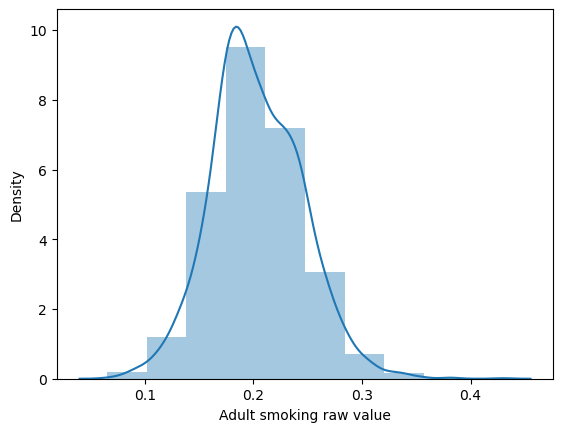

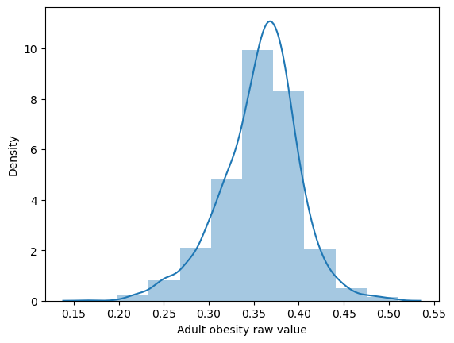

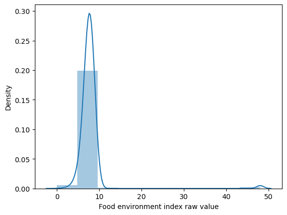

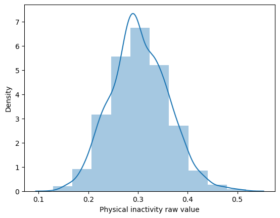

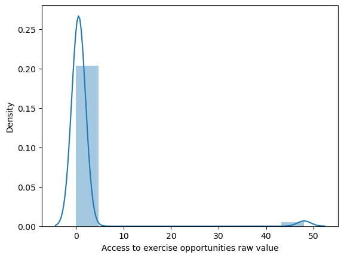

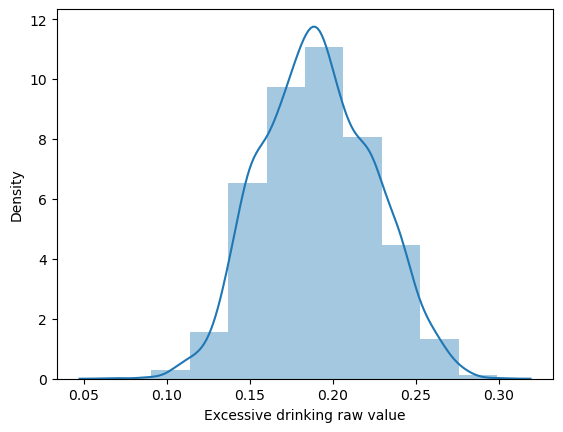

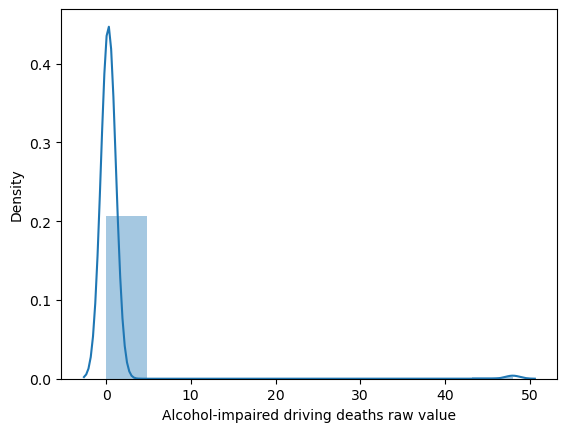

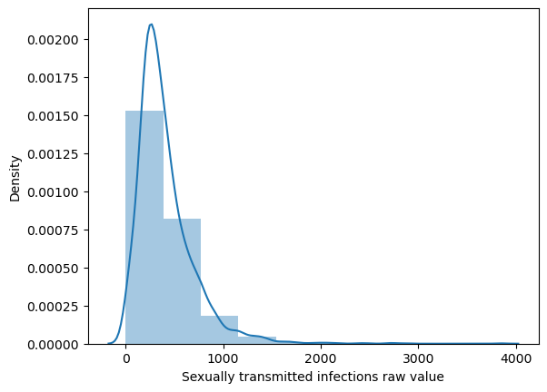

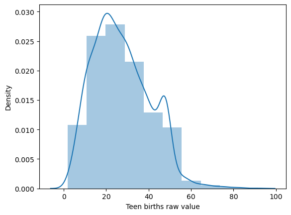

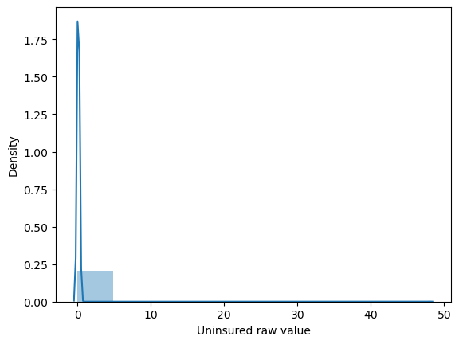

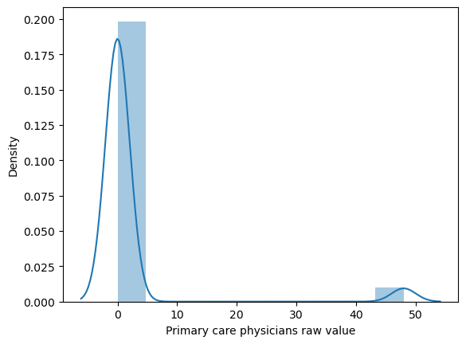

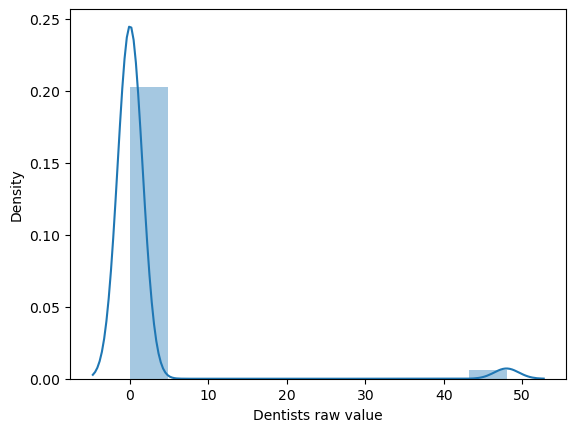

[23 more figures not shown]

```python
# Convert columns containing raw values to float and plot their distribution using seaborn
for column in df.filter(regex='raw').columns:
    df[column] = df[column].astype(float)
    sns.distplot(df[column], bins=10)
    plt.show()
```

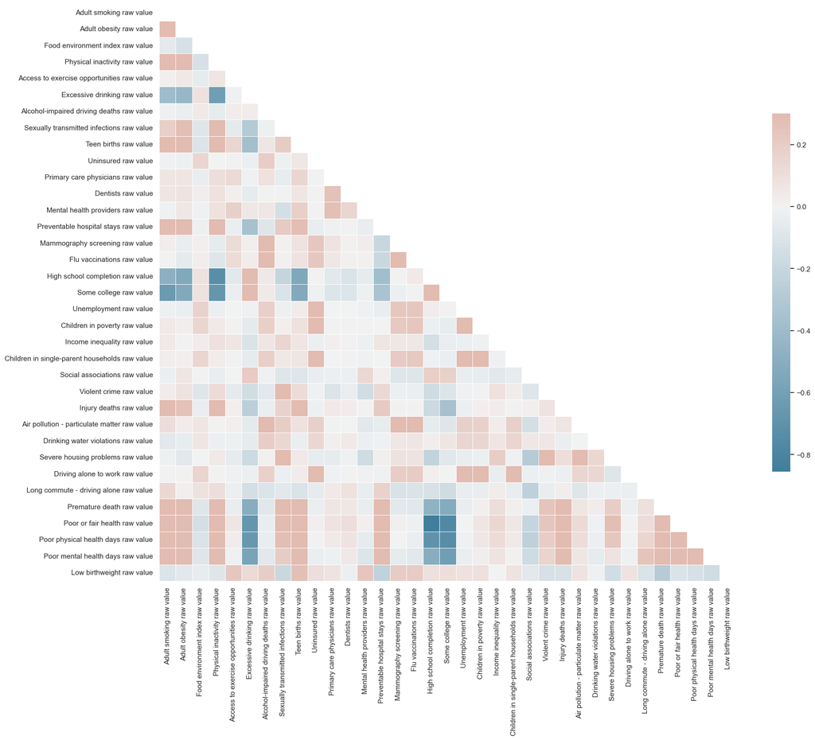

```python
# Create a correlation matrix for the raw value columns and plot it using seaborn (bivariate analysis)
sns.set_theme(style="white")
corr = df.filter(regex='raw').corr()
mask = np.triu(np.ones_like(corr, dtype=bool))

f, ax = plt.subplots(figsize=(20, 20))
cmap = sns.diverging_palette(230, 20, as_cmap=True)
sns.heatmap(corr, mask=mask, cmap=cmap, vmax=.3, center=0,
            square=True, linewidths=.5, cbar_kws={"shrink": .5})
```

```python
#Scaling the raw data using StandardScaler

from sklearn.preprocessing import StandardScaler
df_raw = df.filter(regex='raw')
scaler = StandardScaler()
segmentation_std = scaler.fit_transform(df_raw)

df_raw
```

|  | Adult smoking raw value | Adult obesity raw value | Food environment index raw value | Physical inactivity raw value | Access to exercise opportunities raw value | Excessive drinking raw value | Alcohol-impaired driving deaths raw value | Sexually transmitted infections raw value | Teen births raw value | Uninsured raw value | ... | Air pollution - particulate matter raw value | Drinking water violations raw value | Severe housing problems raw value | Driving alone to work raw value | Long commute - driving alone raw value | Premature death raw value | Poor or fair health raw value | Poor physical health days raw value | Poor mental health days raw value | Low birthweight raw value |
| --- | --- | --- | --- | --- | --- | --- | --- | --- | --- | --- | --- | --- | --- | --- | --- | --- | --- | --- | --- | --- | --- |
| 1 | 0.164926 | 0.321 | 7.8 | 0.259 | 0.797930 | 0.197875 | 0.265551 | 551.0 | 19.300573 | 0.108405 | ... | 7.5 | 0.404545 | 0.173139 | 0.749209 | 0.366 | 7281.935564 | 0.171052 | 3.907359 | 4.526981 | 0.081907 |
| 2 | 0.210927 | 0.363 | 5.3 | 0.308 | 0.566371 | 0.147992 | 0.258870 | 636.9 | 27.598889 | 0.115995 | ... | 9.0 | 0.134328 | 0.136859 | 0.848731 | 0.352 | 10350.071456 | 0.214102 | 4.814633 | 5.618316 | 0.104328 |
| 3 | 0.197000 | 0.353 | 6.5 | 0.322 | 0.627586 | 0.161612 | 0.321429 | 578.1 | 22.976946 | 0.093512 | ... | 9.5 | 0.000000 | 0.147289 | 0.867089 | 0.405 | 8027.394727 | 0.201000 | 4.510042 | 5.419068 | 0.097382 |
| 4 | 0.199000 | 0.296 | 7.4 | 0.276 | 0.745080 | 0.215035 | 0.322034 | 336.0 | 23.734320 | 0.109068 | ... | 7.2 | 0.000000 | 0.124205 | 0.829966 | 0.379 | 8118.358206 | 0.172000 | 4.168866 | 5.173915 | 0.083857 |
| 5 | 0.278000 | 0.404 | 5.7 | 0.416 | 0.498379 | 0.139276 | 0.375000 | 895.2 | 34.700315 | 0.129915 | ... | 9.0 | 0.000000 | 0.154600 | 0.840327 | 0.368 | 12876.760319 | 0.311000 | 5.884415 | 6.109899 | 0.119147 |
| ... | ... | ... | ... | ... | ... | ... | ... | ... | ... | ... | ... | ... | ... | ... | ... | ... | ... | ... | ... | ... | ... |
| 3190 | 0.170000 | 0.335 | 8.1 | 0.252 | 0.830731 | 0.176325 | 0.183333 | 349.5 | 26.687753 | 0.138644 | ... | 5.4 | 0.000000 | 0.100189 | 0.756772 | 0.188 | 8419.275418 | 0.163000 | 3.495993 | 3.933550 | 0.101337 |
| 3191 | 0.113000 | 0.222 | 8.7 | 0.185 | 0.964967 | 0.193689 | 0.181818 | 332.4 | 9.487103 | 0.174560 | ... | 5.2 | 1.000000 | 0.182314 | 0.662721 | 0.156 | 3283.066198 | 0.116000 | 2.779692 | 3.305173 | 0.080655 |
| 3192 | 0.188000 | 0.298 | 8.3 | 0.278 | 0.788806 | 0.181873 | 0.173913 | 267.0 | 25.987107 | 0.140600 | ... | 6.9 | 1.000000 | 0.105365 | 0.793139 | 0.179 | 9358.208153 | 0.172000 | 3.792121 | 4.268578 | 0.095438 |
| 3193 | 0.176000 | 0.289 | 8.3 | 0.259 | 0.762920 | 0.190701 | 0.000000 | 192.2 | 20.905923 | 0.158514 | ... | 5.2 | 0.000000 | 0.084795 | 0.838251 | 0.076 | 7073.941804 | 0.173000 | 3.660729 | 4.040619 | 0.067114 |
| 3194 | 0.192000 | 0.334 | 7.6 | 0.265 | 0.282325 | 0.194183 | 0.222222 | 129.9 | 18.806214 | 0.143161 | ... | 4.3 | 0.000000 | 0.125817 | 0.692444 | 0.212 | 5149.435226 | 0.160000 | 3.703659 | 4.180846 | 0.067982 |

3194 rows × 35 columns

```python
#Initializing PCA and fitting the PCA model to the standardized data

from sklearn.decomposition import PCA

pca = PCA()
pca.fit(segmentation_std)
```

```
PCA()
```

```python
#Calculating the explained variance ratio for each component
pca.explained_variance_ratio_
```

```
array([2.34718858e-01, 1.53694244e-01, 7.34358905e-02, 6.62858397e-02,
       4.30361906e-02, 4.22062652e-02, 3.70787532e-02, 3.07969518e-02,
       2.96369005e-02, 2.68488122e-02, 2.59738098e-02, 2.39860477e-02,
       2.26414139e-02, 2.17784330e-02, 2.03668390e-02, 1.95184376e-02,
       1.82908878e-02, 1.69695107e-02, 1.55338713e-02, 1.50358766e-02,
       1.38293262e-02, 1.06348820e-02, 8.73695169e-03, 7.57211079e-03,
       5.46357443e-03, 4.75056691e-03, 4.22938238e-03, 2.55099682e-03,
       2.05862871e-03, 1.54195919e-03, 4.76094121e-04, 1.39088163e-04,
       1.07720193e-04, 4.72097832e-05, 2.76756609e-05])
```

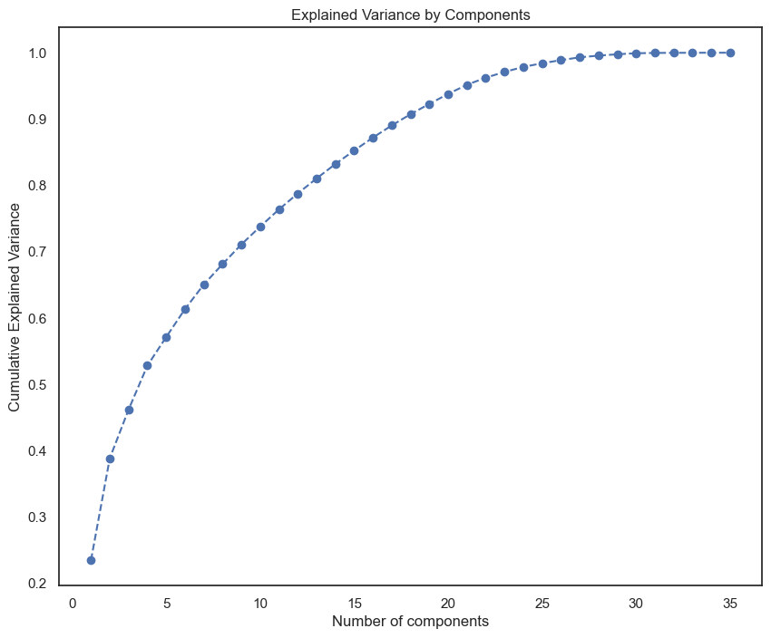

```python
#Plotting the cumulative explained variance for each number of components
plt.figure(figsize = (10,8))
plt.plot(range(1,36), pca.explained_variance_ratio_.cumsum(), marker='o', linestyle='--')
plt.title('Explained Variance by Components')
plt.xlabel('Number of components')
plt.ylabel('Cumulative Explained Variance')
```

```python
#We choose the number of components. 10 seems the right choice according to the previous graph.
pca = PCA(n_components = 10)
pca.fit(segmentation_std)
```

```
PCA(n_components=10)
```

```python
#Transforming the standardized data using the fitted PCA model
pca.transform(segmentation_std)
```

```
array([[-1.68774745, -0.18474994,  0.05988654, ..., -0.23955937,
         0.01087326, -0.14246315],
       [ 1.48124357, -0.09806642, -0.14742191, ..., -0.07288634,
        -0.0873544 ,  0.12896991],
       [ 0.44914893, -0.1343193 , -0.19728416, ...,  0.52455876,
        -0.34777956, -0.2416191 ],
       ...,
       [-1.76688471, -0.1398167 , -0.12420287, ..., -0.53141081,
         0.18339622,  0.75293356],
       [-2.75815741, -0.23216377, -0.71215729, ...,  0.09957681,
        -0.31872796, -0.11449469],
       [-2.61766756, -0.36711662, -0.45381039, ...,  0.31855137,
        -0.31311627, -0.0437866 ]])
```

```python
#Storing the transformed data in scores_pca
scores_pca =  pca.transform(segmentation_std)
```

```python
#Implementing K-means clustering on the transformed data with varying numbers of clusters to determine the optimal number of clusters
from sklearn.cluster import KMeans

wcss = []
for i in range(1,11):
    kmeans_pca = KMeans(n_clusters = i, init = 'k-means++', random_state = 42)
    kmeans_pca.fit(scores_pca)
    wcss.append(kmeans_pca.inertia_)
```

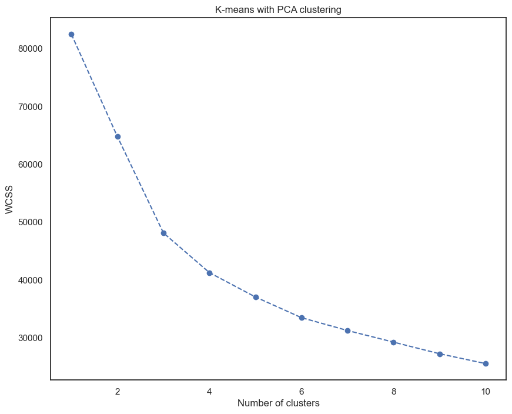

```python
#Plotting the within-cluster sum of squares (WCSS) for each number of clusters
plt.figure(figsize = (10,8))
plt.plot(range(1,11), wcss, marker='o', linestyle='--')
plt.title('K-means with PCA clustering')
plt.xlabel('Number of clusters')
plt.ylabel('WCSS')
plt.show()
```

```python
kmeans_pca = KMeans(n_clusters = 2, init = 'k-means++', random_state = 42)
kmeans_pca.fit(scores_pca)
```

```
KMeans(n_clusters=2, random_state=42)
```

```python
# concatenating the PCA scores with the raw data and renaming the columns for the PCA scores
df_segm_pca_kmeans = pd.concat([df_raw.reset_index(drop = True), pd.DataFrame(scores_pca)], axis = 1)
df_segm_pca_kmeans.columns.values[-10: ] = ['Component1', 'Component2', 'Component3', 'Component4', 'Component5',
                                            'Component6', 'Component7', 'Component8', 'Component9', 'Component10']
df_segm_pca_kmeans['Segment K-means PCA'] = kmeans_pca.predict(scores_pca)
df_segm_pca_kmeans.head()
```

|  | Adult smoking raw value | Adult obesity raw value | Food environment index raw value | Physical inactivity raw value | Access to exercise opportunities raw value | Excessive drinking raw value | Alcohol-impaired driving deaths raw value | Sexually transmitted infections raw value | Teen births raw value | Uninsured raw value | ... | Component2 | Component3 | Component4 | Component5 | Component6 | Component7 | Component8 | Component9 | Component10 | Segment K-means PCA |
| --- | --- | --- | --- | --- | --- | --- | --- | --- | --- | --- | --- | --- | --- | --- | --- | --- | --- | --- | --- | --- | --- |
| 0 | 0.164926 | 0.321 | 7.8 | 0.259 | 0.797930 | 0.197875 | 0.265551 | 551.0 | 19.300573 | 0.108405 | ... | -0.184750 | 0.059887 | 1.564224 | 0.097097 | -0.819794 | -0.229395 | -0.239559 | 0.010873 | -0.142463 | 0 |
| 1 | 0.210927 | 0.363 | 5.3 | 0.308 | 0.566371 | 0.147992 | 0.258870 | 636.9 | 27.598889 | 0.115995 | ... | -0.098066 | -0.147422 | 1.146063 | 0.247553 | 0.090728 | -0.374819 | -0.072886 | -0.087354 | 0.128970 | 1 |
| 2 | 0.197000 | 0.353 | 6.5 | 0.322 | 0.627586 | 0.161612 | 0.321429 | 578.1 | 22.976946 | 0.093512 | ... | -0.134319 | -0.197284 | 0.821273 | -0.330316 | -0.230382 | -0.272113 | 0.524559 | -0.347780 | -0.241619 | 1 |
| 3 | 0.199000 | 0.296 | 7.4 | 0.276 | 0.745080 | 0.215035 | 0.322034 | 336.0 | 23.734320 | 0.109068 | ... | -0.233754 | -0.367844 | 0.298777 | -0.819337 | -0.043783 | -0.115624 | -0.208688 | 0.253622 | 0.279407 | 0 |
| 4 | 0.278000 | 0.404 | 5.7 | 0.416 | 0.498379 | 0.139276 | 0.375000 | 895.2 | 34.700315 | 0.129915 | ... | 0.195980 | 0.165480 | 0.886311 | -0.115514 | -0.733319 | -0.961077 | 0.454771 | -0.536539 | -0.181366 | 1 |

5 rows × 46 columns

```python
# using k-means clustering to assign each data point to a segment
df_segm_pca_kmeans['Segment'] = df_segm_pca_kmeans['Segment K-means PCA'].map({0: 'first', 1: 'second'})
```

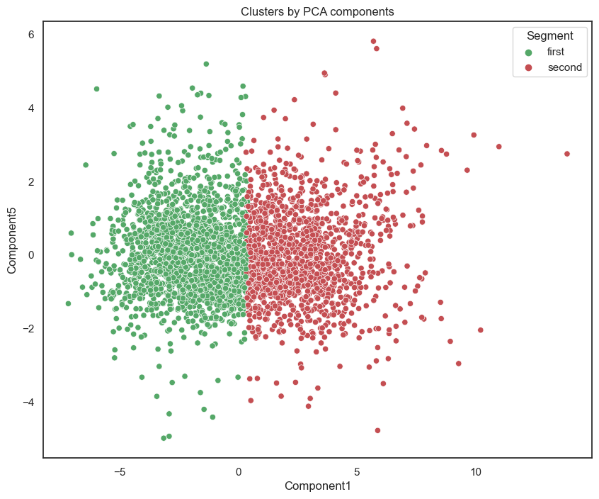

```python
# mapping the cluster labels to segment names and plotting the data points
x_axis = df_segm_pca_kmeans['Component1']
y_axis = df_segm_pca_kmeans['Component5']
plt.figure(figsize = (10,8))
sns.scatterplot(x_axis, y_axis, hue = df_segm_pca_kmeans['Segment'], palette = ['g', 'r'])
plt.title('Clusters by PCA components')
plt.show()
```

```python
# selecting specific columns from the original dataframe and merging with the segmented data
cols = ['State FIPS Code', 'County FIPS Code', '5-digit FIPS Code', 'State Abbreviation', 'Name', 'Release Year','County Ranked (Yes=1/No=0)']
df_temp = df[cols]
df_temp
```

|  | State FIPS Code | County FIPS Code | 5-digit FIPS Code | State Abbreviation | Name | Release Year | County Ranked (Yes=1/No=0) |
| --- | --- | --- | --- | --- | --- | --- | --- |
| 1 | 00 | 000 | 00000 | US | United States | 2022 | 48 |
| 2 | 01 | 000 | 01000 | AL | Alabama | 2022 | 48 |
| 3 | 01 | 001 | 01001 | AL | Autauga County | 2022 | 1 |
| 4 | 01 | 003 | 01003 | AL | Baldwin County | 2022 | 1 |
| 5 | 01 | 005 | 01005 | AL | Barbour County | 2022 | 1 |
| ... | ... | ... | ... | ... | ... | ... | ... |
| 3190 | 56 | 37 | 56037 | WY | Sweetwater County | 2022 | 1.0 |
| 3191 | 56 | 39 | 56039 | WY | Teton County | 2022 | 1.0 |
| 3192 | 56 | 41 | 56041 | WY | Uinta County | 2022 | 1.0 |
| 3193 | 56 | 43 | 56043 | WY | Washakie County | 2022 | 1.0 |
| 3194 | 56 | 45 | 56045 | WY | Weston County | 2022 | 1.0 |

3194 rows × 7 columns

```python
df_temp.index -= 1
df_temp
```

|  | State FIPS Code | County FIPS Code | 5-digit FIPS Code | State Abbreviation | Name | Release Year | County Ranked (Yes=1/No=0) |
| --- | --- | --- | --- | --- | --- | --- | --- |
| 0 | 00 | 000 | 00000 | US | United States | 2022 | 48 |
| 1 | 01 | 000 | 01000 | AL | Alabama | 2022 | 48 |
| 2 | 01 | 001 | 01001 | AL | Autauga County | 2022 | 1 |
| 3 | 01 | 003 | 01003 | AL | Baldwin County | 2022 | 1 |
| 4 | 01 | 005 | 01005 | AL | Barbour County | 2022 | 1 |
| ... | ... | ... | ... | ... | ... | ... | ... |
| 3189 | 56 | 37 | 56037 | WY | Sweetwater County | 2022 | 1.0 |
| 3190 | 56 | 39 | 56039 | WY | Teton County | 2022 | 1.0 |
| 3191 | 56 | 41 | 56041 | WY | Uinta County | 2022 | 1.0 |
| 3192 | 56 | 43 | 56043 | WY | Washakie County | 2022 | 1.0 |
| 3193 | 56 | 45 | 56045 | WY | Weston County | 2022 | 1.0 |

3194 rows × 7 columns

```python
df_merged = pd.concat([df_segm_pca_kmeans, df_temp], axis=1)
df_merged
```

|  | Adult smoking raw value | Adult obesity raw value | Food environment index raw value | Physical inactivity raw value | Access to exercise opportunities raw value | Excessive drinking raw value | Alcohol-impaired driving deaths raw value | Sexually transmitted infections raw value | Teen births raw value | Uninsured raw value | ... | Component10 | Segment K-means PCA | Segment | State FIPS Code | County FIPS Code | 5-digit FIPS Code | State Abbreviation | Name | Release Year | County Ranked (Yes=1/No=0) |
| --- | --- | --- | --- | --- | --- | --- | --- | --- | --- | --- | --- | --- | --- | --- | --- | --- | --- | --- | --- | --- | --- |
| 0 | 0.164926 | 0.321 | 7.8 | 0.259 | 0.797930 | 0.197875 | 0.265551 | 551.0 | 19.300573 | 0.108405 | ... | -0.142463 | 0 | first | 00 | 000 | 00000 | US | United States | 2022 | 48 |
| 1 | 0.210927 | 0.363 | 5.3 | 0.308 | 0.566371 | 0.147992 | 0.258870 | 636.9 | 27.598889 | 0.115995 | ... | 0.128970 | 1 | second | 01 | 000 | 01000 | AL | Alabama | 2022 | 48 |
| 2 | 0.197000 | 0.353 | 6.5 | 0.322 | 0.627586 | 0.161612 | 0.321429 | 578.1 | 22.976946 | 0.093512 | ... | -0.241619 | 1 | second | 01 | 001 | 01001 | AL | Autauga County | 2022 | 1 |
| 3 | 0.199000 | 0.296 | 7.4 | 0.276 | 0.745080 | 0.215035 | 0.322034 | 336.0 | 23.734320 | 0.109068 | ... | 0.279407 | 0 | first | 01 | 003 | 01003 | AL | Baldwin County | 2022 | 1 |
| 4 | 0.278000 | 0.404 | 5.7 | 0.416 | 0.498379 | 0.139276 | 0.375000 | 895.2 | 34.700315 | 0.129915 | ... | -0.181366 | 1 | second | 01 | 005 | 01005 | AL | Barbour County | 2022 | 1 |
| ... | ... | ... | ... | ... | ... | ... | ... | ... | ... | ... | ... | ... | ... | ... | ... | ... | ... | ... | ... | ... | ... |
| 3189 | 0.170000 | 0.335 | 8.1 | 0.252 | 0.830731 | 0.176325 | 0.183333 | 349.5 | 26.687753 | 0.138644 | ... | 0.393287 | 0 | first | 56 | 37 | 56037 | WY | Sweetwater County | 2022 | 1.0 |
| 3190 | 0.113000 | 0.222 | 8.7 | 0.185 | 0.964967 | 0.193689 | 0.181818 | 332.4 | 9.487103 | 0.174560 | ... | -0.224622 | 0 | first | 56 | 39 | 56039 | WY | Teton County | 2022 | 1.0 |
| 3191 | 0.188000 | 0.298 | 8.3 | 0.278 | 0.788806 | 0.181873 | 0.173913 | 267.0 | 25.987107 | 0.140600 | ... | 0.752934 | 0 | first | 56 | 41 | 56041 | WY | Uinta County | 2022 | 1.0 |
| 3192 | 0.176000 | 0.289 | 8.3 | 0.259 | 0.762920 | 0.190701 | 0.000000 | 192.2 | 20.905923 | 0.158514 | ... | -0.114495 | 0 | first | 56 | 43 | 56043 | WY | Washakie County | 2022 | 1.0 |
| 3193 | 0.192000 | 0.334 | 7.6 | 0.265 | 0.282325 | 0.194183 | 0.222222 | 129.9 | 18.806214 | 0.143161 | ... | -0.043787 | 0 | first | 56 | 45 | 56045 | WY | Weston County | 2022 | 1.0 |

3194 rows × 54 columns

```python
# selecting the data points for each segment and printing the county names
counties_1 = df_merged.loc[df_merged['Segment K-means PCA']== 0]
counties_1['Name']
```

```
0           United States
3          Baldwin County
40      Lauderdale County
42             Lee County
43       Limestone County
              ...
3189    Sweetwater County
3190         Teton County
3191         Uinta County
3192      Washakie County
3193        Weston County
Name: Name, Length: 1834, dtype: object
```

```python
# selecting the data points for each segment and printing the county names
counties_2 = df_merged.loc[df_merged['Segment K-means PCA']== 1]
counties_2['Name']
```

```
1                Alabama
2         Autauga County
4         Barbour County
5            Bibb County
6          Blount County
              ...
3093       Wetzel County
3094         Wirt County
3095         Wood County
3096      Wyoming County
3137    Menominee County
Name: Name, Length: 1360, dtype: object
```

```python
df_merged
```

|  | Adult smoking raw value | Adult obesity raw value | Food environment index raw value | Physical inactivity raw value | Access to exercise opportunities raw value | Excessive drinking raw value | Alcohol-impaired driving deaths raw value | Sexually transmitted infections raw value | Teen births raw value | Uninsured raw value | ... | Component10 | Segment K-means PCA | Segment | State FIPS Code | County FIPS Code | 5-digit FIPS Code | State Abbreviation | Name | Release Year | County Ranked (Yes=1/No=0) |
| --- | --- | --- | --- | --- | --- | --- | --- | --- | --- | --- | --- | --- | --- | --- | --- | --- | --- | --- | --- | --- | --- |
| 0 | 0.164926 | 0.321 | 7.8 | 0.259 | 0.797930 | 0.197875 | 0.265551 | 551.0 | 19.300573 | 0.108405 | ... | -0.142463 | 0 | first | 00 | 000 | 00000 | US | United States | 2022 | 48 |
| 1 | 0.210927 | 0.363 | 5.3 | 0.308 | 0.566371 | 0.147992 | 0.258870 | 636.9 | 27.598889 | 0.115995 | ... | 0.128970 | 1 | second | 01 | 000 | 01000 | AL | Alabama | 2022 | 48 |
| 2 | 0.197000 | 0.353 | 6.5 | 0.322 | 0.627586 | 0.161612 | 0.321429 | 578.1 | 22.976946 | 0.093512 | ... | -0.241619 | 1 | second | 01 | 001 | 01001 | AL | Autauga County | 2022 | 1 |
| 3 | 0.199000 | 0.296 | 7.4 | 0.276 | 0.745080 | 0.215035 | 0.322034 | 336.0 | 23.734320 | 0.109068 | ... | 0.279407 | 0 | first | 01 | 003 | 01003 | AL | Baldwin County | 2022 | 1 |
| 4 | 0.278000 | 0.404 | 5.7 | 0.416 | 0.498379 | 0.139276 | 0.375000 | 895.2 | 34.700315 | 0.129915 | ... | -0.181366 | 1 | second | 01 | 005 | 01005 | AL | Barbour County | 2022 | 1 |
| ... | ... | ... | ... | ... | ... | ... | ... | ... | ... | ... | ... | ... | ... | ... | ... | ... | ... | ... | ... | ... | ... |
| 3189 | 0.170000 | 0.335 | 8.1 | 0.252 | 0.830731 | 0.176325 | 0.183333 | 349.5 | 26.687753 | 0.138644 | ... | 0.393287 | 0 | first | 56 | 37 | 56037 | WY | Sweetwater County | 2022 | 1.0 |
| 3190 | 0.113000 | 0.222 | 8.7 | 0.185 | 0.964967 | 0.193689 | 0.181818 | 332.4 | 9.487103 | 0.174560 | ... | -0.224622 | 0 | first | 56 | 39 | 56039 | WY | Teton County | 2022 | 1.0 |
| 3191 | 0.188000 | 0.298 | 8.3 | 0.278 | 0.788806 | 0.181873 | 0.173913 | 267.0 | 25.987107 | 0.140600 | ... | 0.752934 | 0 | first | 56 | 41 | 56041 | WY | Uinta County | 2022 | 1.0 |
| 3192 | 0.176000 | 0.289 | 8.3 | 0.259 | 0.762920 | 0.190701 | 0.000000 | 192.2 | 20.905923 | 0.158514 | ... | -0.114495 | 0 | first | 56 | 43 | 56043 | WY | Washakie County | 2022 | 1.0 |
| 3193 | 0.192000 | 0.334 | 7.6 | 0.265 | 0.282325 | 0.194183 | 0.222222 | 129.9 | 18.806214 | 0.143161 | ... | -0.043787 | 0 | first | 56 | 45 | 56045 | WY | Weston County | 2022 | 1.0 |

3194 rows × 54 columns

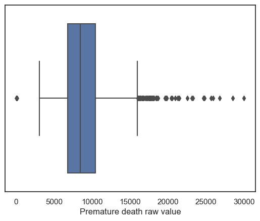

```python
df_merged['Premature death raw value'] = df_merged['Premature death raw value'].astype(float)
sns.boxplot(x = 'Premature death raw value', data = df_merged)
```

Removing outliers from the data and splitting the data into training and testing sets

```python
df_merged = df_merged[df_merged['Premature death raw value']<20000]
```

```python
from sklearn.model_selection import train_test_split
```

```python
X = df_merged.filter(regex='raw value')
X = X.loc[:, X.columns != 'Premature death raw value']
y = df_merged['Premature death raw value']
```

```python
X_train, X_test, y_train, y_test = train_test_split(X, y, test_size = 0.3, random_state = 42)
```

```python
# scaling the data using StandardScaler and applying Lasso, Ridge, and ElasticNet models with GridSearchCV
# apply scaling
scaler = StandardScaler()
# fit on training dataset only
scaler.fit(X_train)
# transform training dataset
X_train = scaler.transform(X_train)
# transform testing dataset
X_test = scaler.transform(X_test)
```

```python
from sklearn.linear_model import Ridge, Lasso, ElasticNet
from sklearn.model_selection import GridSearchCV
from sklearn.metrics import r2_score, mean_squared_error
```

```python
# printing the cross-validated mean RMSE and R2 for each model
params = {'alpha': [20, 18, 16, 14, 12, 10, 5, 1, 0.1, 0.01]}
ridge = Ridge()
lasso = Lasso()
e_net = ElasticNet()

for model in [ridge, lasso, e_net]:
    cv = GridSearchCV(model, params, cv = 5, scoring = ['neg_mean_squared_error', 'r2'], refit = 'neg_mean_squared_error')
    cv.fit(X_train, y_train)

    RMSE = (-cv.best_score_.mean())**(1/2)
    print('model: ', model)
    print('cross-validated mean RMSE: {:.3f}'.format(RMSE))
    mean_R2 = cv.cv_results_['mean_test_r2'].mean()
    print('cross-validated mean R2: {:.3f}'.format(mean_R2))
    print('best model parameter: ', cv.best_estimator_, '\n')
```

```
model:  Ridge()
cross-validated mean RMSE: 3462.631
cross-validated mean R2: -9.952
best model parameter:  Ridge(alpha=20)
```

[output not shown]

```
model:  Lasso()
cross-validated mean RMSE: 1532.107
cross-validated mean R2: -9.396
best model parameter:  Lasso(alpha=20)

model:  ElasticNet()
cross-validated mean RMSE: 1520.807
cross-validated mean R2: 0.231
best model parameter:  ElasticNet(alpha=1)
```

```python
lm = Lasso(alpha = 20)
lm.fit(X_train, y_train)
y_pred = lm.predict(X_test)

print('Test R2: {:.3f}'.format(r2_score(y_test, y_pred)))
print('Test RMSE: {:.3f}'.format((mean_squared_error(y_test, y_pred))**(1/2)))
```

```
Test R2: 0.767
Test RMSE: 1417.454
```

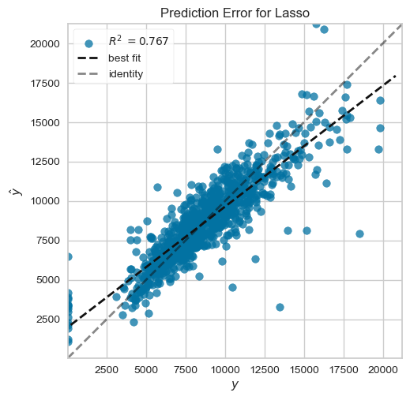

```python
# Create a PredictionError visualizer using Yellowbrick library with lm (linear model) as input
# and X_train, y_train, X_test, y_test as train-test split inputs
from yellowbrick.regressor import prediction_error

visualizer = prediction_error(lm, X_train, y_train, X_test, y_test)
```

```python
# Get absolute value of linear model coefficients, and extract corresponding feature names to a pandas DataFrame
importance = np.abs(lm.coef_)

features = X.columns

# Sort the feature coefficients in descending order to find the top 5 important features
feat_importance = pd.DataFrame([features, importance]).transpose()
feat_importance.rename(columns = {0: 'feature', 1: 'coefficient'}, inplace=True)
feat_importance.sort_values(by = 'coefficient', ascending = False)
```

|  | feature | coefficient |
| --- | --- | --- |
| 24 | Injury deaths raw value | 1197.652921 |
| 7 | Sexually transmitted infections raw value | 470.394067 |
| 33 | Low birthweight raw value | 435.548788 |
| 30 | Poor or fair health raw value | 364.081211 |
| 32 | Poor mental health days raw value | 313.928826 |
| 1 | Adult obesity raw value | 216.958029 |
| 8 | Teen births raw value | 212.926634 |
| 0 | Adult smoking raw value | 180.56106 |
| 3 | Physical inactivity raw value | 174.255602 |
| 13 | Preventable hospital stays raw value | 172.894168 |
| 22 | Social associations raw value | 157.922188 |
| 5 | Excessive drinking raw value | 149.459022 |
| 4 | Access to exercise opportunities raw value | 146.525863 |
| 23 | Violent crime raw value | 117.552661 |
| 10 | Primary care physicians raw value | 66.357231 |
| 29 | Long commute - driving alone raw value | 63.948947 |
| 26 | Drinking water violations raw value | 36.239027 |
| 20 | Income inequality raw value | 31.228525 |
| 2 | Food environment index raw value | 18.343737 |
| 11 | Dentists raw value | 17.629979 |
| 18 | Unemployment raw value | 3.367249 |
| 16 | High school completion raw value | 1.560444 |
| 6 | Alcohol-impaired driving deaths raw value | 0.0 |
| 28 | Driving alone to work raw value | 0.0 |
| 31 | Poor physical health days raw value | 0.0 |
| 27 | Severe housing problems raw value | 0.0 |
| 21 | Children in single-parent households raw value | 0.0 |
| 25 | Air pollution - particulate matter raw value | 0.0 |
| 9 | Uninsured raw value | 0.0 |
| 19 | Children in poverty raw value | 0.0 |
| 15 | Flu vaccinations raw value | 0.0 |
| 14 | Mammography screening raw value | 0.0 |
| 12 | Mental health providers raw value | 0.0 |
| 17 | Some college raw value | 0.0 |

```python
importance = np.abs(lm.coef_)

features = X.columns

feat_importance = pd.DataFrame([features, importance]).transpose()
feat_importance.rename(columns = {0: 'feature', 1: 'coefficient'}, inplace=True)
feat_importance.sort_values(by = 'coefficient', ascending = False)
```

|  | feature | coefficient |
| --- | --- | --- |
| 24 | Injury deaths raw value | 1197.652921 |
| 7 | Sexually transmitted infections raw value | 470.394067 |
| 33 | Low birthweight raw value | 435.548788 |
| 30 | Poor or fair health raw value | 364.081211 |
| 32 | Poor mental health days raw value | 313.928826 |
| 1 | Adult obesity raw value | 216.958029 |
| 8 | Teen births raw value | 212.926634 |
| 0 | Adult smoking raw value | 180.56106 |
| 3 | Physical inactivity raw value | 174.255602 |
| 13 | Preventable hospital stays raw value | 172.894168 |
| 22 | Social associations raw value | 157.922188 |
| 5 | Excessive drinking raw value | 149.459022 |
| 4 | Access to exercise opportunities raw value | 146.525863 |
| 23 | Violent crime raw value | 117.552661 |
| 10 | Primary care physicians raw value | 66.357231 |
| 29 | Long commute - driving alone raw value | 63.948947 |
| 26 | Drinking water violations raw value | 36.239027 |
| 20 | Income inequality raw value | 31.228525 |
| 2 | Food environment index raw value | 18.343737 |
| 11 | Dentists raw value | 17.629979 |
| 18 | Unemployment raw value | 3.367249 |
| 16 | High school completion raw value | 1.560444 |
| 6 | Alcohol-impaired driving deaths raw value | 0.0 |
| 28 | Driving alone to work raw value | 0.0 |
| 31 | Poor physical health days raw value | 0.0 |
| 27 | Severe housing problems raw value | 0.0 |
| 21 | Children in single-parent households raw value | 0.0 |
| 25 | Air pollution - particulate matter raw value | 0.0 |
| 9 | Uninsured raw value | 0.0 |
| 19 | Children in poverty raw value | 0.0 |
| 15 | Flu vaccinations raw value | 0.0 |
| 14 | Mammography screening raw value | 0.0 |
| 12 | Mental health providers raw value | 0.0 |
| 17 | Some college raw value | 0.0 |

The top 5 features are the top 5 values in the table with highest coefficient.

```python
# Instantiate a Random Forest Regressor and specify a grid of parameters to search over using GridSearchCV
from sklearn.ensemble import RandomForestRegressor

rf = RandomForestRegressor(random_state = 42)

params = {'n_estimators': [100, 150, 300],
             'max_depth': [10, 25, 50, 60]}

cv = GridSearchCV(rf, params, cv = 5, scoring = ['neg_mean_squared_error', 'r2'], refit = 'neg_mean_squared_error')
cv.fit(X_train, y_train)
```

```
GridSearchCV(cv=5, estimator=RandomForestRegressor(random_state=42),
             param_grid={'max_depth': [10, 25, 50, 60],
                         'n_estimators': [100, 150, 300]},
             refit='neg_mean_squared_error',
             scoring=['neg_mean_squared_error', 'r2'])
```

```python
# Calculate the Root Mean Squared Error (RMSE) and R2 score using cross-validation
RMSE = (-cv.best_score_.mean())**(1/2)
print('model: Random Forest')
print('cross-validated mean RMSE: {:.3f}'.format(RMSE))
mean_R2 = cv.cv_results_['mean_test_r2'].mean()
print('cross-validated mean R2: {:.3f}'.format(mean_R2))
print('best model parameter: ', cv.best_estimator_, '\n')
```

```
model: Random Forest
cross-validated mean RMSE: 1397.126
cross-validated mean R2: 0.771
best model parameter:  RandomForestRegressor(max_depth=25, random_state=42)
```

The best Random Forest model achieved slightly better performace than the Lasso regression, with the best parameters being max_depth = 25. The R2 is around 77% and RMSE is slightly lower than the Lasso CV value, at 1397.

```python
# Fit a Random Forest Regressor with the best parameters determined by GridSearchCV, and make predictions on the test set
rf = RandomForestRegressor(n_estimators = 150, max_depth = 60, random_state = 42)
rf.fit(X_train, y_train)
y_pred = rf.predict(X_test)

# Calculate the R2 score and RMSE on the test set
print('Test R2: {:.3f}'.format(r2_score(y_test, y_pred)))
print('Test RMSE: {:.3f}'.format((mean_squared_error(y_test, y_pred))**(1/2)))
```

```
Test R2: 0.784
Test RMSE: 1365.628
```

When tested on the test data, the RF regressor performed slightly better than the Lasso regression, achieving 78% R2 and an RMSE of 1366. Hence, I deem Random Regressor model as the better model here.

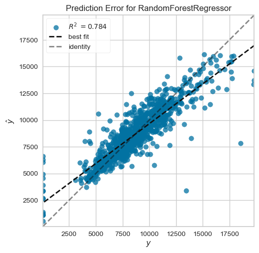

```python
# Create a PredictionError visualizer using the Random Forest Regressor and train-test split inputs
visualizer = prediction_error(rf, X_train, y_train, X_test, y_test)
```

```python
# Get feature importances from the Random Forest Regressor and extract corresponding feature names to a pandas DataFrame
importance = np.abs(rf.feature_importances_)

features = X.columns

# Sort the feature importances in descending order to find the top 5 important features
feat_importance = pd.DataFrame([features, importance]).transpose()
feat_importance.rename(columns = {0: 'feature', 1: 'importance'}, inplace=True)
feat_importance.sort_values(by = 'importance', ascending = False)
```

|  | feature | importance |
| --- | --- | --- |
| 24 | Injury deaths raw value | 0.224094 |
| 30 | Poor or fair health raw value | 0.208193 |
| 31 | Poor physical health days raw value | 0.196414 |
| 19 | Children in poverty raw value | 0.055927 |
| 33 | Low birthweight raw value | 0.030857 |
| 10 | Primary care physicians raw value | 0.027256 |
| 22 | Social associations raw value | 0.023691 |
| 21 | Children in single-parent households raw value | 0.020904 |
| 7 | Sexually transmitted infections raw value | 0.01694 |
| 8 | Teen births raw value | 0.016025 |
| 3 | Physical inactivity raw value | 0.015516 |
| 12 | Mental health providers raw value | 0.014196 |
| 1 | Adult obesity raw value | 0.011411 |
| 28 | Driving alone to work raw value | 0.010679 |
| 5 | Excessive drinking raw value | 0.010355 |
| 18 | Unemployment raw value | 0.00962 |
| 13 | Preventable hospital stays raw value | 0.009047 |
| 32 | Poor mental health days raw value | 0.008787 |
| 20 | Income inequality raw value | 0.008289 |
| 17 | Some college raw value | 0.008264 |
| 23 | Violent crime raw value | 0.007244 |
| 0 | Adult smoking raw value | 0.006406 |
| 11 | Dentists raw value | 0.006324 |
| 2 | Food environment index raw value | 0.006028 |
| 6 | Alcohol-impaired driving deaths raw value | 0.005831 |
| 14 | Mammography screening raw value | 0.005772 |
| 4 | Access to exercise opportunities raw value | 0.005537 |
| 29 | Long commute - driving alone raw value | 0.005252 |
| 16 | High school completion raw value | 0.005197 |
| 15 | Flu vaccinations raw value | 0.005027 |
| 27 | Severe housing problems raw value | 0.005014 |
| 9 | Uninsured raw value | 0.004897 |
| 25 | Air pollution - particulate matter raw value | 0.003996 |
| 26 | Drinking water violations raw value | 0.001013 |

```python
# Extract and display specific columns from the data frame for Allegheny County
cols = ['Injury deaths raw value', 'Poor or fair health raw value', 'Poor physical health days raw value', 'Children in poverty raw value', 'Low birthweight raw value']
df[df['Name']=='Allegheny County'][cols].transpose()
```

|  | 2286 |
| --- | --- |
| Injury deaths raw value | 108.019536 |
| Poor or fair health raw value | 0.165000 |
| Poor physical health days raw value | 3.723379 |
| Children in poverty raw value | 0.130000 |
| Low birthweight raw value | 0.084120 |

```python
df[cols].describe().transpose()
```

|  | count | mean | std | min | 25% | 50% | 75% | max |
| --- | --- | --- | --- | --- | --- | --- | --- | --- |
| Injury deaths raw value | 3194.0 | 90.477970 | 27.558863 | 19.930828 | 71.912179 | 88.481752 | 104.974324 | 280.112045 |
| Poor or fair health raw value | 3194.0 | 0.205681 | 0.050162 | 0.089000 | 0.166000 | 0.200000 | 0.241000 | 0.448000 |
| Poor physical health days raw value | 3194.0 | 4.334505 | 0.750069 | 2.501610 | 3.749233 | 4.303930 | 4.824688 | 7.795640 |
| Children in poverty raw value | 3194.0 | 0.201256 | 0.849953 | 0.026000 | 0.126000 | 0.175000 | 0.233000 | 48.000000 |
| Low birthweight raw value | 3194.0 | 1.672399 | 8.584663 | 0.028871 | 0.068609 | 0.080376 | 0.093236 | 48.000000 |

In Allegheny county, there is below average proportion of children in poverty, low birthweight, poor or fair health, and poor physical health days, compared to other counties in the U.S.. However, the county has higher rates of injury deaths, a factor that is most important in predicting premature deaths. Public health efforts should focus on education with regard to community safety, as well as other policy mechanisms to curb such injuries or fatal accidents.